# Point pattern analysis for Ki67/PDGFR-β in the ipsilateral hemisphere

Data analysis notebook

Author

Affiliation

Daniel Manrique-Castano, PhD

Univerisity Laval

Published

Friday, April 5, 2024

Keywords

Ki67, PDGFR-β, Brain injury, Cell proliferation, Bayesian modeling

# 1 Preview

This notebook reports the point pattern analysis for Ki67 in the ipsilateral hemisphere following cerebral ischemia.

**Parent dataset:** Ki67 and PDGFR-β stained ischemic hemispheres imaged at 10x (with stitching). Samples are grouped at 0 (Sham), 3, 7, 14, and 30 days post-ischemia (DPI). The raw images and pre-processing scripts (if applicable) are available at the Zenodo repository (10.5281/zenodo.10553084) under the name `Widefield_10x_Ipsilateral_Ki67-Pdgfrb.zip`.

# 2 Install and load required packages

Install and load all required packages. Please uncomment (delete #) the line code if installation is required. Load the installed libraries each time you start a new R session.

```r
#install.packages("devtools")
library(devtools)

#install.packages(c("dplyr", "ggplot","plyr", "spatstat", "tidyverse"))

library(dplyr)
library(ggplot2)
library(plyr)
library(spatstat)
library(tidyverse)
```

# 3 Visual themes

We create a visual theme to use in our plots (ggplots).

```r
Plot_theme <- theme_classic() +
  theme(
      plot.title = element_text(size=18, hjust = 0.5, face="bold"),
      plot.subtitle = element_text(size = 10, color = "black"),
      plot.caption = element_text(size = 12, color = "black"),
      axis.line = element_line(colour = "black", size = 1.5, linetype = "solid"),
      axis.ticks.length=unit(7,"pt"),

      axis.title.x = element_text(colour = "black", size = 16),
      axis.text.x = element_text(colour = "black", size = 16, angle = 0, hjust = 0.5),
      axis.ticks.x = element_line(colour = "black", size = 1),

      axis.title.y = element_text(colour = "black", size = 16),
      axis.text.y = element_text(colour = "black", size = 16),
      axis.ticks.y = element_line(colour = "black", size = 1),

      legend.position="right",
      legend.direction="vertical",
      legend.title = element_text(colour="black", face="bold", size=12),
      legend.text = element_text(colour="black", size=10),

      plot.margin = margin(t = 10,  # Top margin
                             r = 2,  # Right margin
                             b = 10,  # Bottom margin
                             l = 10) # Left margin
      )
```

# 4 Load and handle the datasets

We load the `Data_Raw/Widefield_10x_Pdgfrb-Ki67_Coloc/Ki67_Filtered.csv` and `Data_Raw/Widefield_10x_Pdgfrb-Ki67_Coloc/Pdgfrb_Filtered.csv` and `Data_Raw/Widefield_10x_Pdgfrb-Ki67_Coloc/Pdgfrb_Ki67_Colocalized.csv` datasets. These are heavy data sets containing information about individual cells detected in the ipsilateral hemisphere.

```r
# We load the dataset in case is not present in the R environment
Ki67_Cells <- read.csv(file = "Data_Raw/Widefield_10x_Pdgfrb-Ki67_Coloc/Ki67_Filtered.csv", header = TRUE)

Pdgfrb_Cells <- read.csv(file = "Data_Raw/Widefield_10x_Pdgfrb-Ki67_Coloc/Pdgfrb_Filtered.csv", header = TRUE)

Coloc_Cells <- read.csv(file = "Data_Raw/Widefield_10x_Pdgfrb-Ki67_Coloc/Pdgfrb_Ki67_Colocalized.csv", header = TRUE)

knitr::kable(Ki67_Cells [1:10, ])
```

Table 1: Data set

| ImageNumber | ObjectNumber | FileName_Ki67_Color | FileName_Ki67_Mask | FileName_Pdgfrb_Color | FileName_Pdgfrb_Mask | PathName_Ki67_Color | PathName_Ki67_Mask | PathName_Pdgfrb_Color | PathName_Pdgfrb_Mask | Children_Pdgfrb_Ki67_Colocalized_Count | Location_Center_X | Location_Center_Y | Location_Center_Z | Number_Object_Number | Parent_Ki67_Cells | Parent_Pdgfrb_Filtered |
| --- | --- | --- | --- | --- | --- | --- | --- | --- | --- | --- | --- | --- | --- | --- | --- | --- |
| 1 | 1 | Td010_7D_MCAO.tif_Ki67.png | Td010_7D_MCAO_Ki67_Segmentation.png | Td010_7D_MCAO.tif_Pdgfrb.png | Td010_7D_MCAO_Pdgfrb_Segmentation.png | E:_PDGFRb_Reactivity_Ipsi_KI67-Pdgfrb_10x_Ipsilateral_Ki67-Pdgfrb_PNG | E:_PDGFRb_Reactivity_Ipsi_KI67-Pdgfrb_10x_Ipsilateral_Ki67-Pdgfrb_Segmentation_Mask | E:_PDGFRb_Reactivity_Ipsi_KI67-Pdgfrb_10x_Ipsilateral_Ki67-Pdgfrb_PNG | E:_PDGFRb_Reactivity_Ipsi_KI67-Pdgfrb_10x_Ipsilateral_Ki67-Pdgfrb_Segmentation_Mask | 0 | 1230.3636 | 22.63636 | 0 | 1 | 1 | 0 |
| 1 | 2 | Td010_7D_MCAO.tif_Ki67.png | Td010_7D_MCAO_Ki67_Segmentation.png | Td010_7D_MCAO.tif_Pdgfrb.png | Td010_7D_MCAO_Pdgfrb_Segmentation.png | E:_PDGFRb_Reactivity_Ipsi_KI67-Pdgfrb_10x_Ipsilateral_Ki67-Pdgfrb_PNG | E:_PDGFRb_Reactivity_Ipsi_KI67-Pdgfrb_10x_Ipsilateral_Ki67-Pdgfrb_Segmentation_Mask | E:_PDGFRb_Reactivity_Ipsi_KI67-Pdgfrb_10x_Ipsilateral_Ki67-Pdgfrb_PNG | E:_PDGFRb_Reactivity_Ipsi_KI67-Pdgfrb_10x_Ipsilateral_Ki67-Pdgfrb_Segmentation_Mask | 0 | 649.2667 | 342.06667 | 0 | 2 | 3 | 0 |
| 1 | 3 | Td010_7D_MCAO.tif_Ki67.png | Td010_7D_MCAO_Ki67_Segmentation.png | Td010_7D_MCAO.tif_Pdgfrb.png | Td010_7D_MCAO_Pdgfrb_Segmentation.png | E:_PDGFRb_Reactivity_Ipsi_KI67-Pdgfrb_10x_Ipsilateral_Ki67-Pdgfrb_PNG | E:_PDGFRb_Reactivity_Ipsi_KI67-Pdgfrb_10x_Ipsilateral_Ki67-Pdgfrb_Segmentation_Mask | E:_PDGFRb_Reactivity_Ipsi_KI67-Pdgfrb_10x_Ipsilateral_Ki67-Pdgfrb_PNG | E:_PDGFRb_Reactivity_Ipsi_KI67-Pdgfrb_10x_Ipsilateral_Ki67-Pdgfrb_Segmentation_Mask | 0 | 521.3061 | 377.93878 | 0 | 3 | 4 | 0 |
| 1 | 4 | Td010_7D_MCAO.tif_Ki67.png | Td010_7D_MCAO_Ki67_Segmentation.png | Td010_7D_MCAO.tif_Pdgfrb.png | Td010_7D_MCAO_Pdgfrb_Segmentation.png | E:_PDGFRb_Reactivity_Ipsi_KI67-Pdgfrb_10x_Ipsilateral_Ki67-Pdgfrb_PNG | E:_PDGFRb_Reactivity_Ipsi_KI67-Pdgfrb_10x_Ipsilateral_Ki67-Pdgfrb_Segmentation_Mask | E:_PDGFRb_Reactivity_Ipsi_KI67-Pdgfrb_10x_Ipsilateral_Ki67-Pdgfrb_PNG | E:_PDGFRb_Reactivity_Ipsi_KI67-Pdgfrb_10x_Ipsilateral_Ki67-Pdgfrb_Segmentation_Mask | 0 | 541.0833 | 386.16667 | 0 | 4 | 5 | 0 |
| 1 | 5 | Td010_7D_MCAO.tif_Ki67.png | Td010_7D_MCAO_Ki67_Segmentation.png | Td010_7D_MCAO.tif_Pdgfrb.png | Td010_7D_MCAO_Pdgfrb_Segmentation.png | E:_PDGFRb_Reactivity_Ipsi_KI67-Pdgfrb_10x_Ipsilateral_Ki67-Pdgfrb_PNG | E:_PDGFRb_Reactivity_Ipsi_KI67-Pdgfrb_10x_Ipsilateral_Ki67-Pdgfrb_Segmentation_Mask | E:_PDGFRb_Reactivity_Ipsi_KI67-Pdgfrb_10x_Ipsilateral_Ki67-Pdgfrb_PNG | E:_PDGFRb_Reactivity_Ipsi_KI67-Pdgfrb_10x_Ipsilateral_Ki67-Pdgfrb_Segmentation_Mask | 0 | 572.0000 | 387.00000 | 0 | 5 | 6 | 0 |
| 1 | 6 | Td010_7D_MCAO.tif_Ki67.png | Td010_7D_MCAO_Ki67_Segmentation.png | Td010_7D_MCAO.tif_Pdgfrb.png | Td010_7D_MCAO_Pdgfrb_Segmentation.png | E:_PDGFRb_Reactivity_Ipsi_KI67-Pdgfrb_10x_Ipsilateral_Ki67-Pdgfrb_PNG | E:_PDGFRb_Reactivity_Ipsi_KI67-Pdgfrb_10x_Ipsilateral_Ki67-Pdgfrb_Segmentation_Mask | E:_PDGFRb_Reactivity_Ipsi_KI67-Pdgfrb_10x_Ipsilateral_Ki67-Pdgfrb_PNG | E:_PDGFRb_Reactivity_Ipsi_KI67-Pdgfrb_10x_Ipsilateral_Ki67-Pdgfrb_Segmentation_Mask | 0 | 1011.6667 | 387.00000 | 0 | 6 | 7 | 0 |
| 1 | 7 | Td010_7D_MCAO.tif_Ki67.png | Td010_7D_MCAO_Ki67_Segmentation.png | Td010_7D_MCAO.tif_Pdgfrb.png | Td010_7D_MCAO_Pdgfrb_Segmentation.png | E:_PDGFRb_Reactivity_Ipsi_KI67-Pdgfrb_10x_Ipsilateral_Ki67-Pdgfrb_PNG | E:_PDGFRb_Reactivity_Ipsi_KI67-Pdgfrb_10x_Ipsilateral_Ki67-Pdgfrb_Segmentation_Mask | E:_PDGFRb_Reactivity_Ipsi_KI67-Pdgfrb_10x_Ipsilateral_Ki67-Pdgfrb_PNG | E:_PDGFRb_Reactivity_Ipsi_KI67-Pdgfrb_10x_Ipsilateral_Ki67-Pdgfrb_Segmentation_Mask | 0 | 465.5000 | 388.00000 | 0 | 7 | 8 | 0 |
| 1 | 8 | Td010_7D_MCAO.tif_Ki67.png | Td010_7D_MCAO_Ki67_Segmentation.png | Td010_7D_MCAO.tif_Pdgfrb.png | Td010_7D_MCAO_Pdgfrb_Segmentation.png | E:_PDGFRb_Reactivity_Ipsi_KI67-Pdgfrb_10x_Ipsilateral_Ki67-Pdgfrb_PNG | E:_PDGFRb_Reactivity_Ipsi_KI67-Pdgfrb_10x_Ipsilateral_Ki67-Pdgfrb_Segmentation_Mask | E:_PDGFRb_Reactivity_Ipsi_KI67-Pdgfrb_10x_Ipsilateral_Ki67-Pdgfrb_PNG | E:_PDGFRb_Reactivity_Ipsi_KI67-Pdgfrb_10x_Ipsilateral_Ki67-Pdgfrb_Segmentation_Mask | 0 | 514.0556 | 388.22222 | 0 | 8 | 9 | 0 |
| 1 | 9 | Td010_7D_MCAO.tif_Ki67.png | Td010_7D_MCAO_Ki67_Segmentation.png | Td010_7D_MCAO.tif_Pdgfrb.png | Td010_7D_MCAO_Pdgfrb_Segmentation.png | E:_PDGFRb_Reactivity_Ipsi_KI67-Pdgfrb_10x_Ipsilateral_Ki67-Pdgfrb_PNG | E:_PDGFRb_Reactivity_Ipsi_KI67-Pdgfrb_10x_Ipsilateral_Ki67-Pdgfrb_Segmentation_Mask | E:_PDGFRb_Reactivity_Ipsi_KI67-Pdgfrb_10x_Ipsilateral_Ki67-Pdgfrb_PNG | E:_PDGFRb_Reactivity_Ipsi_KI67-Pdgfrb_10x_Ipsilateral_Ki67-Pdgfrb_Segmentation_Mask | 0 | 456.0833 | 391.83333 | 0 | 9 | 10 | 0 |
| 1 | 10 | Td010_7D_MCAO.tif_Ki67.png | Td010_7D_MCAO_Ki67_Segmentation.png | Td010_7D_MCAO.tif_Pdgfrb.png | Td010_7D_MCAO_Pdgfrb_Segmentation.png | E:_PDGFRb_Reactivity_Ipsi_KI67-Pdgfrb_10x_Ipsilateral_Ki67-Pdgfrb_PNG | E:_PDGFRb_Reactivity_Ipsi_KI67-Pdgfrb_10x_Ipsilateral_Ki67-Pdgfrb_Segmentation_Mask | E:_PDGFRb_Reactivity_Ipsi_KI67-Pdgfrb_10x_Ipsilateral_Ki67-Pdgfrb_PNG | E:_PDGFRb_Reactivity_Ipsi_KI67-Pdgfrb_10x_Ipsilateral_Ki67-Pdgfrb_Segmentation_Mask | 0 | 586.0000 | 394.20000 | 0 | 10 | 11 | 0 |

Given the weight of these files, they are not provided in the GitHub repository but in the OSF repository. From the tables (taking Ki67_Cells as an example), we are interested in the `FileName_Ki67_Color`column containing the identification data for the images, and `Location_Center_X` and `Location_Center_Y`signaling the xy coordinates of each Ki67+ cells. The same apply for Pdgfrb_Cells and Coloc_Cells.

Next, we subset the dataset to select the columns of interest and give them meaningful names.

```r
### For Ki67

## We subset the relevant columns (cell number)
Ki67_Data <- subset(Ki67_Cells, select = c("FileName_Ki67_Color", "Location_Center_X", "Location_Center_Y"))

## And extract metadata from the image name
Ki67_Data  <- cbind(Ki67_Data, do.call(rbind , strsplit(Ki67_Data$FileName_Ki67_Color, "[_\\.]"))[,1:2])

Ki67_Data <- subset(Ki67_Data, select = -c(FileName_Ki67_Color))

## We Rename the relevant columns
colnames(Ki67_Data) <- c("CenterX", "CenterY", "MouseID", "DPI")

## We set the factors
Ki67_Data$DPI <- factor(Ki67_Data$DPI, levels = c("0D", "3D", "7D", "14D", "30D"))

write.csv(Ki67_Data, "Data_Processed/Widefield_10x_Ipsilateral_Ki67_Cells.csv", row.names = FALSE)


### For Pdgfrb

## We subset the relevant columns (cell number)
Pdgfrb_Data <- subset(Pdgfrb_Cells, select = c("FileName_Pdgfrb_Color", "Location_Center_X", "Location_Center_Y"))

## And extract metadata from the image name
Pdgfrb_Data  <- cbind(Pdgfrb_Data, do.call(rbind , strsplit(Pdgfrb_Data$FileName_Pdgfrb_Color, "[_\\.]"))[,1:2])

Pdgfrb_Data <- subset(Pdgfrb_Data, select = -c(FileName_Pdgfrb_Color))

## We Rename the relevant columns
colnames(Pdgfrb_Data) <- c("CenterX", "CenterY", "MouseID", "DPI")

## We set the factors
Pdgfrb_Data$DPI <- factor(Pdgfrb_Data$DPI, levels = c("0D", "3D", "7D", "14D", "30D"))

write.csv(Pdgfrb_Data, "Data_Processed/Widefield_10x_Ipsilateral_Pdgfrb_Cells.csv", row.names = FALSE)

### For Coloc

## We subset the relevant columns (cell number)
Coloc_Data <- subset(Coloc_Cells, select = c("FileName_Ki67_Color", "Location_Center_X", "Location_Center_Y"))

## And extract metadata from the image name
Coloc_Data  <- cbind(Coloc_Data, do.call(rbind , strsplit(Coloc_Data$FileName_Ki67_Color, "[_\\.]"))[,1:2])

Coloc_Data <- subset(Coloc_Data, select = -c(FileName_Ki67_Color))

## We Rename the relevant columns
colnames(Coloc_Data) <- c("CenterX", "CenterY", "MouseID", "DPI")

## We set the factors
Coloc_Data$DPI <- factor(Coloc_Data$DPI, levels = c("0D", "3D", "7D", "14D", "30D"))

write.csv(Coloc_Data, "Data_Processed/Widefield_10x_Ipsilateral_Coloc_Cells.csv", row.names = FALSE)
```

With the data handled, we create point patterns to perform point pattern analysis (PPA). With this approach, we can estimate the spatial intensity of colocalized cells and their distribution relative to covariates. For more information on PPA, please refer to the `Widefield_10x_Pdgfrb-Gfap_Covariance`notebook.

# 5 Generate and handle point patterns

We use functions from the `spatstat’ package to create point patterns based on the coordinates of individual cells. The point patterns are then stored in a hyperframe and can be loaded into R as an R object.

Table 3

```r
# Initialize the hyperframe as NULL at the start
Result_Hyperframe <- NULL

# Adjusted add_to_hyperframe function to dynamically build the hyperframe
add_to_hyperframe <- function(...) {
  if (is.null(Result_Hyperframe)) {
    Result_Hyperframe <<- hyperframe(...)
  } else {
    Result_Hyperframe <<- tryCatch({
      rbind(Result_Hyperframe, hyperframe(...))
    }, error = function(e) {
      cat("Error in rbind: ", e$message, "\n")
    })
  }
}

# Adjusted function to create point patterns
create_point_pattern <- function(Data_Subset) {
  xlim <- range(Data_Subset$CenterX)
  ylim <- range(Data_Subset$CenterY)

  Cells_PPP <- spatstat.geom::ppp(x = Data_Subset$CenterX, y = Data_Subset$CenterY, xrange = xlim, yrange = ylim)
  unitname(Cells_PPP) <- list("mm", "mm", 1.936/6624)
  Cells_PPP <- spatstat.geom::rescale(Cells_PPP)

  return(Cells_PPP)
}

# Iterate over unique MouseIDs to process and create point patterns for both Klf4 and Dapi
mouse_ids <- unique(Ki67_Data$MouseID)

for (mouse_id in mouse_ids) {
  Subset_Ki67 <- Ki67_Data[Ki67_Data$MouseID == mouse_id, ]
  Subset_Pdgfrb <- Pdgfrb_Data[Pdgfrb_Data$MouseID == mouse_id, ]
  Subset_Coloc <- Coloc_Data[Coloc_Data$MouseID == mouse_id, ]

  if(nrow(Subset_Ki67) > 0 && nrow(Subset_Pdgfrb) > 0) {
    Ki67_PPP <- create_point_pattern(Subset_Ki67)
    Pdgfrb_PPP <- create_point_pattern(Subset_Pdgfrb)
    Coloc_PPP <- create_point_pattern(Subset_Coloc)

    # Set the observation window for Klf4 based on Dapi's convex hull
    Window(Ki67_PPP) <- convexhull(Pdgfrb_PPP)
    Window(Pdgfrb_PPP) <- convexhull(Pdgfrb_PPP)
    Window(Coloc_PPP) <- convexhull(Pdgfrb_PPP)

    dpi2_value <- unique(Subset_Ki67$DPI)[1]

    add_to_hyperframe(Ki67 = Ki67_PPP, Pdgfrb = Pdgfrb_PPP, Coloc = Coloc_PPP, ID = as.character(mouse_id), DPI = as.factor(dpi2_value), stringsAsFactors = TRUE)
  } else {
    message(sprintf("Skipping MouseID %s due to insufficient data.\n", mouse_id))
  }
}

# Save the Result_Hyperframe
Result_Hyperframe$DPI <- factor(Result_Hyperframe$DPI, levels = c("0D", "3D", "7D", "14D", "30D"))

saveRDS(Result_Hyperframe, "PointPatterns/Widefield_10x_Ipsilateral_Ki67-Pdgfrb.rds")
```

The point patterns are stored as an R-object. In the next chunk, we load the point patterns and add density kernels. Please check the `Widefield_10x_Pdgfrb-Gfap_Covariance`notebook for more information in this regard.

# 6 Calculate density kernels

We use the `density` function to calculate density kernels with a sigma of 0.02.

Table 4

```r
# Load the point patterns
PointPatterns <- readRDS("PointPatterns/Widefield_10x_Ipsilateral_Ki67-Pdgfrb.rds")

# Add density kernels to the hyperframe
PointPatterns$Ki67_Density <- with (PointPatterns, density(Ki67, sigma = 0.02))
PointPatterns$Pdgfrb_Density <- with (PointPatterns, density(Pdgfrb, sigma = 0.02))
PointPatterns$Coloc_Density <- with (PointPatterns, density(Coloc, sigma = 0.02))
```

## 6.1 Plot density kernels

We plot some examples of the density kernels. Please not that the coordinates are y-fliped for unknown reason to us.

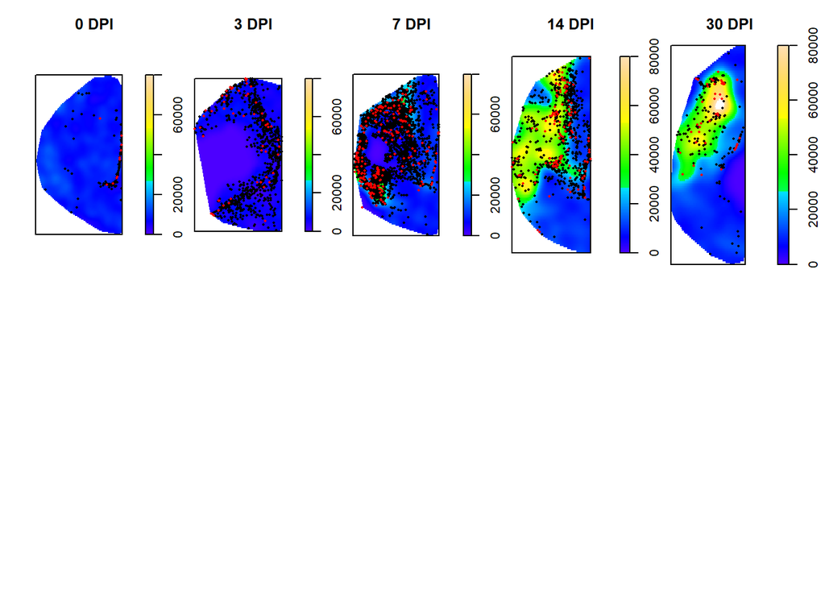

```r
Pdgfrb_Colmap <- colourmap(topo.colors(256), range = c(0, 80000))

par(mfrow = c(2,5), mar=c(1,1,1,1), oma=c(1,1,1,1))

## For Pdgfrb (density) and Ki67 (dots)

plot(PointPatterns$Pdgfrb_Density$`138`, col = Pdgfrb_Colmap, main = "0 DPI")
plot(PointPatterns$Ki67$`138`, add = TRUE, pch = 16, cex= 0.4, col = "black")
plot(PointPatterns$Coloc$`138`, add = TRUE, pch = 16, cex= 0.4, col = "red")

plot(PointPatterns$Pdgfrb_Density$`140`, col = Pdgfrb_Colmap, main = "3 DPI")
plot(PointPatterns$Ki67$`140`, add = TRUE, pch = 16, cex= 0.4, col = "black")
plot(PointPatterns$Coloc$`140`, add = TRUE, pch = 16, cex= 0.4, col = "red")

plot(PointPatterns$Pdgfrb_Density$`130`, col = Pdgfrb_Colmap, main = "7 DPI")
plot(PointPatterns$Ki67$`130`, add = TRUE, pch = 16, cex= 0.4, col = "black")
plot(PointPatterns$Coloc$`130`, add = TRUE, pch = 16, cex= 0.4, col = "red")

plot(PointPatterns$Pdgfrb_Density$`122`, col = Pdgfrb_Colmap, main = "14 DPI")
plot(PointPatterns$Ki67$`122`, add = TRUE, pch = 16, cex= 0.4, col = "black")
plot(PointPatterns$Coloc$`122`, add = TRUE, pch = 16, cex= 0.4, col = "red")

plot(PointPatterns$Pdgfrb_Density$`113`, col = Pdgfrb_Colmap, main = "30 DPI")
plot(PointPatterns$Ki67$`113`, add = TRUE, pch = 16, cex= 0.4, col = "black")
plot(PointPatterns$Coloc$`113`, add = TRUE, pch = 16, cex= 0.4, col = "red")
```

Figure 1 shows examples per DPI.

# 7 Modeling point pattern process

Now, we use the `mppm` function from `spatstat` (*2*)to fit a **log-linear model** for replicated point patterns. This model allow us to quantify Ki67 allocation changes conditional on the spatial intensity (density) of PDGFR-β in the ischemic hemisphere. We the PDGFR-β spatial intensity as predictor. The model specification is as follows:

$$Ki67_i(x) \sim \text{Poisson}(\lambda(x, \text{DPI}_i))$$

where $i$ indexes the point pattern (corresponding to a unique DPI), and $x$ represents the spatial intensity of PDGFR-β. The intensity function $\lambda(x, \text{DPI}_i)$ is modeled as:

$$\log(\lambda(x, \text{DPI}_i)) = \beta_0 + \beta_1 x + u_{0i} + u_{1i}x$$
Where $\beta_0$ and $\beta_1$ are fixed effects, representing the baseline log intensity of Ki67 expression and the effect of the PDGFR-β spatial intensity, respectively.$u_{0i}$ and $u_{1i}$ are random effects for the intercept and slope, varying by DPI, to capture the variability in Ki67 expression its spatial variation across different injury stages.

## 7.1 Fit the mppm model

We fit the model using the `mppm` function for replicated point patterns:

```r
Ki67_mppm <- mppm(Ki67 ~ Pdgfrb_Density, random = ~ Pdgfrb_Density | DPI, data = PointPatterns)
```

```
iteration 1
iteration 2
iteration 3
iteration 4
iteration 5
iteration 6
iteration 7
```

```r
summary(Ki67_mppm)
```

```
Point process model fitted to 50 point patterns
Call: mppm(Ki67 ~ Pdgfrb_Density, random = ~Pdgfrb_Density | DPI, data =
PointPatterns)
Log trend formula: ~Pdgfrb_Density

Fixed effects:
   (Intercept) Pdgfrb_Density
  6.856056e+00   7.268634e-05
Random effects:
    (Intercept) Pdgfrb_Density
0D   -1.4507421  -2.123332e-05
3D    0.5937362   1.073640e-04
7D    0.6309940   7.053063e-06
14D   0.8067449  -5.162329e-05
30D  -0.5807329  -4.156049e-05
All fitted coefficients:
   (Intercept) Pdgfrb_Density
  6.856056e+00   7.268634e-05

Random effects summary:
Random effects:
 Formula: ~Pdgfrb_Density | DPI
 Structure: General positive-definite, Log-Cholesky parametrization
               StdDev       Corr
(Intercept)    5.002805e+00 (Intr)
Pdgfrb_Density 3.984932e-05 -0.974
Residual       1.000000e+00

Variance function:
 Structure: fixed weights
 Formula: ~invwt

Interaction for all patterns:
Poisson process


--- Gory details: ---
Combined data frame has 214478 rows
Linear mixed-effects model fit by maximum likelihood
  Data: moadf
```

[output cut: 14 more lines]

```
 Formula: ~invwt
Fixed effects:  .mpl.Y ~ Pdgfrb_Density
                  Value Std.Error     DF  t-value p-value
(Intercept)    6.856056  3.236941 214472 2.118066  0.0342
Pdgfrb_Density 0.000073  0.000026 214472 2.798698  0.0051
 Correlation:
               (Intr)
Pdgfrb_Density -0.968

Standardized Within-Group Residuals:
       Min         Q1        Med         Q3        Max
-1.6563455 -0.3197718 -0.2530356 -0.1883027 24.9437904

Number of Observations: 214478
Number of Groups: 5
```

Overall, these results indicate that Ki67 is expressed in regions populated by (reactive) PDGFR-β cells, specially at 3 and 7 DPI. We generate a representative visualization using `rhohat` to visualize this trend.

First, we subset the point patterns

```r
PointPatterns_7D <- subset(PointPatterns, DPI=="7D", select = 1:8)
PointPatterns_30D <- subset(PointPatterns, DPI=="30D", select = 1:8)
```

Now, we calculate the relative distribution of Ki67 conditional of the spatial intensity of PDGFR-β+ cells.

```r
# For 7 DPI
Ki67_7D <- with(PointPatterns_7D, spatstat.explore::rhohat.ppp(Ki67, Pdgfrb_Density, do.CI = FALSE))
Ki67_7D <- pool(Ki67_7D)

# For 30 DPI
Ki67_30D <- with(PointPatterns_30D, spatstat.explore::rhohat.ppp(Ki67, Pdgfrb_Density, do.CI = FALSE))
Ki67_30D <- pool(Ki67_30D)
```

Finally, we plot the `rhohat`.

### 7.1.1 8.2.3 Plot the rhohat

Now, we plot the calculated relative distribution.

```r
## For 7D

png("Plots/Widefield_10x_Ki67-Pdgfrb/Ki67_Pdgfrb_Rhohat_7D.png", width = 700, height = 350)
par(mar=c(7,8,2,2))
par(las=1)
plot(Ki67_7D,
      shade = c("lorho", "hirho"),
     main=NULL,
     las=1,
     legendargs=list(xpd=TRUE),
     lwd = 6,
     legend=FALSE,
     xlab = "",
     ylab = "",
     xaxt = "n",
     yaxt = "n")

axis(1, at = seq(0, 18000, 3000), labels = c("0",  "3k", "6k", "9k", "12k", "15k", "18k"), cex.axis=2.5, padj = 0.5, lwd.ticks = 5)

axis(2, at = seq(0, 18000, 3000), labels = c("0",  "3k", "6k", "9k", "12k", "15k", "18k"), cex.axis=2.5, padj = 0.5, lwd.ticks = 5)

title(xlab = "PDGFR-β (intensity)", mgp = c(4.5, 1, 0), cex.lab = 3)
title(ylab = "p(Ki67)", mgp = c(5, 1, 0), cex.lab = 3)

dev.off()
```

```r
## For 30D

png("Plots/Widefield_10x_Ki67-Pdgfrb/Ki67_Pdgfrb_Rhohat_30D.png", width = 700, height = 350)
par(mar=c(7,8,2,2))
par(las=1)
plot(Ki67_30D,
      shade = c("lorho", "hirho"),
     main=NULL,
     las=1,
     legendargs=list(xpd=TRUE),
     lwd = 6,
     legend=FALSE,
     xlab = "",
     ylab = "",
     xaxt = "n",
     yaxt = "n")

axis(1, at = seq(0, 30000, 5000), labels = c("0",  "5k", "10k", "15k", "20k", "25k", "30k"), cex.axis=2.5, padj = 0.5, lwd.ticks = 5)

axis(2, at = seq(0, 18000, 3000), labels = c("0",  "3k", "6k", "9k", "12k", "15k", "18k"), cex.axis=2.5, padj = 0.5, lwd.ticks = 5)

title(xlab = "PDGFR-β (intensity)", mgp = c(4.5, 1, 0), cex.lab = 3)
title(ylab = "p(Ki67)", mgp = c(5, 1, 0), cex.lab = 3)

dev.off()
```

The images are saved in a dedicated folder and displayed in the research article.

# 8 References

1.

D. R. Stirling, M. J. Swain-Bowden, A. M. Lucas, A. E. Carpenter, B. A. Cimini, A. Goodman, CellProfiler 4: improvements in speed, utility and usability. *BMC Bioinformatics*. **22** (2021), doi:10.1186/s12859-021-04344-9.

2.

A. Baddeley, E. Rubak, R. Turner, Spatial point patterns: Methodology and applications with r (2015) (available at https://www.routledge.com/Spatial-Point-Patterns-Methodology-and-Applications-with-R/Baddeley-Rubak-Turner/p/book/9781482210200/).